# LAB1a:Assignment1

Eser Comak

November 13, 2018

# Install & Load packages

```r
library(ggplot2)
library(plyr)
library(plotfunctions)
library(gridExtra)
library(ggplot2)
library(itsadug)
```

## Part I. Inspection of the data

# Load datafile and get the head&tail

```r
load("data_for_assignment1_2.rda")

head(datafile, n = 10) # inspect the first 10 elements
```

```
##    Subjekt Trial        name_city1        name_city2 city1 city2 acc_vp
## 1       96     1           Swindon           Bristol     U     R      1
## 2       96     2           Swindon   Southend-on-Sea     U     U      0
## 3       96     3    Stoke-on-Trent          Aberdeen     U     R      0
## 4       96     4 Oldbury/Smethwick              York     U     R      0
## 5       96     5          Brighton         Stockport     R     U      0
## 6       96     6           Belfast            Oxford     R     R      1
## 7       96     7            Oxford         Sheffield     R     R      1
## 8       96     8           Bristol     Huddersfield      R     U      1
## 9       96     9           Bristol Oldbury/Smethwick     R     U      1
## 10      96    10        Nottingham              York     R     R      1
##    rt_vp
## 1   2018
## 2   1684
## 3   1948
## 4   1775
## 5   1746
## 6   2664
## 7   2425
## 8   1150
## 9   1228
## 10  3661
```

```r
tail(datafile)         # inspect last 6 elements
```

```
##      Subjekt Trial      name_city1      name_city2 city1 city2 acc_vp
## 4795     135   115 Southend-on-Sea        Aberdeen     U     R      1
## 4796     135   116         Bristol            York     R     R      1
## 4797     135   117      Nottingham  Stoke-on-Trent     R     U      0
## 4798     135   118        Brighton           Poole     R     U      0
## 4799     135   119       Sheffield Southend-on-Sea     R     U      1
## 4800     135   120        Aberdeen   West Bromwich     R     U      1
##      rt_vp
## 4795  1021
## 4796  1901
## 4797  1661
## 4798  1256
## 4799  1077
## 4800  1290
```

## Question-1

# Measurements

```r
# convert these columns to factor (see help(factor) fore more information):
datafile$city1 <- as.factor(datafile$city1)
datafile$city2 <- as.factor(datafile$city2)
# inspect data:
str(datafile)
```

```
## 'data.frame':    4800 obs. of  8 variables:
##  $ Subjekt   : int  96 96 96 96 96 96 96 96 96 96 ...
##  $ Trial     : int  1 2 3 4 5 6 7 8 9 10 ...
##  $ name_city1: chr  "Swindon" "Swindon" "Stoke-on-Trent" "Oldbury/Smethwick" ...
##  $ name_city2: chr  "Bristol" "Southend-on-Sea" "Aberdeen" "York" ...
##  $ city1     : Factor w/ 2 levels "R","U": 2 2 2 2 1 1 1 1 1 1 ...
##  $ city2     : Factor w/ 2 levels "R","U": 1 2 1 1 2 1 1 2 2 1 ...
##  $ acc_vp    : int  1 0 0 0 0 1 1 1 1 1 ...
##  $ rt_vp     : int  2018 1684 1948 1775 1746 2664 2425 1150 1228 3661 ...
```

```r
is.integer(datafile$rt_vp)
```

```
## [1] TRUE
```

```r
is.numeric(datafile$rt_vp)
```

```
## [1] TRUE
```

```r
class(datafile$rt_vp)
```

```
## [1] "integer"
```

```r
is.character(datafile$name_city1)
```

```
## [1] TRUE
```

```r
is.factor(datafile$name_city1)
```

```
## [1] FALSE
```

```r
class(datafile$name_city1)
```

```
## [1] "character"
```

```r
unique(datafile$name_city1)
```

```
##  [1] "Swindon"            "Stoke-on-Trent"     "Oldbury/Smethwick"
##  [4] "Brighton"           "Belfast"            "Oxford"
##  [7] "Bristol"            "Nottingham"         "Poole"
## [10] "Birmingham"         "Kingston upon Hall" "Sheffield"
## [13] "West Bromwich"      "Stockport"          "Glasgow"
## [16] "Aberdeen"           "Huddersfield "      "York"
## [19] "Walsall"            "Southend-on-Sea"    "Edinburgh"
```

```r
is.factor(datafile$city1)
```

```
## [1] TRUE
```

```r
levels(datafile$city1)
```

```
## [1] "R" "U"
```

```r
unique(datafile$city1)
```

```
## [1] U R
## Levels: R U
```

## Question-1

# Conditions

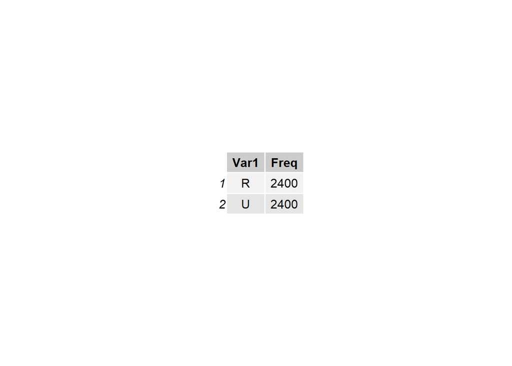

```r
#howmany U and R cities in city1
tableUR<-table(datafile$city1)
grid.table(as.data.frame(tableUR))
```

```r
#which cities are presented together
table(datafile$name_city1,datafile$name_city2)
```

```
##
##                      Aberdeen Belfast Birmingham Brighton Bristol
##   Aberdeen                  0      22          0        0      28
##   Belfast                   0       0          0       17      21
##   Birmingham               22      21          0        0      24
##   Brighton                 19       0         17        0      24
##   Bristol                   0       0          0        0       0
##   Edinburgh                 0       0         19        0      21
##   Glasgow                  26       0          0       11      22
##   Huddersfield             40       0          0       40       0
##   Kingston upon Hall        0       0          0        0      40
##   Nottingham                0      22          0       20      27
##   Oldbury/Smethwick        40       0          0       40       0
##   Oxford                   23       0         22       20       0
##   Poole                     0       0          0        0      40
##   Sheffield                 0       0         18        0       0
##   Southend-on-Sea          40       0          0       40       0
##   Stockport                 0       0          0        0      40
##   Stoke-on-Trent           40       0          0       40       0
##   Swindon                   0       0          0        0      40
##   Walsall                  40       0          0       40       0
##   West Bromwich             0       0          0        0      40
##   York                      0      17         19        0       0
##
##                      Edinburgh Glasgow Huddersfield  Kingston upon Hall
##   Aberdeen                  20       0             0                 40
##   Belfast                   28      25             0                  0
##   Birmingham                 0      23             0                  0
##   Brighton                  19       0             0                 40
##   Bristol                    0       0            40                  0
##   Edinburgh                  0       0             0                  0
##   Glasgow                   20       0             0                  0
##   Huddersfield               0       0             0                  0
##   Kingston upon Hall         0       0            40                  0
##   Nottingham                21      19            40                  0
##   Oldbury/Smethwick          0       0            40                  0
##   Oxford                    24       0             0                  0
##   Poole                      0       0            40                  0
##   Sheffield                 19       0            40                  0
##   Southend-on-Sea            0       0            40                  0
```

[output cut: 60 more lines]

```
##   Glasgow                  0             0   26
##   Huddersfield             0             0   40
##   Kingston upon Hall       0             0    0
##   Nottingham              40             0   21
##   Oldbury/Smethwick       40             0   40
##   Oxford                   0             0    0
##   Poole                    0            40    0
##   Sheffield               40             0    0
##   Southend-on-Sea          0             0   40
##   Stockport                0            40    0
##   Stoke-on-Trent           0             0   40
##   Swindon                  0             0    0
##   Walsall                  0            40   40
##   West Bromwich            0             0    0
##   York                     0            40    0
```

```r
#Belfast,Glasgow,Oxford,Poole has the highest variation considering the match between other possible cities

#is.element(x, y) is identical to x %in% y and setdiff and intersect is identical as well
"Belfast" %in% datafile$name_city1
```

```
## [1] TRUE
```

```r
is.element("Belfast", datafile$name_city1)
```

```
## [1] TRUE
```

```r
setdiff(datafile$name_city1,datafile$name_city2)
```

```
## character(0)
```

```r
intersect(datafile$name_city1,datafile$name_city2)
```

```
##  [1] "Swindon"            "Stoke-on-Trent"     "Oldbury/Smethwick"
##  [4] "Brighton"           "Belfast"            "Oxford"
##  [7] "Bristol"            "Nottingham"         "Poole"
## [10] "Birmingham"         "Kingston upon Hall" "Sheffield"
## [13] "West Bromwich"      "Stockport"          "Glasgow"
## [16] "Aberdeen"           "Huddersfield "      "York"
## [19] "Walsall"            "Southend-on-Sea"    "Edinburgh"
```

## Question-3

# Subjects

```r
#change column name from Subjekt to Subject
colnames(datafile)[1] <- "Subject"
#how many subjects
length(unique(datafile$Subject))
```

```
## [1] 40
```

```r
#trial per subject
data.frame(table(datafile$Subject))
```

```
##    Var1 Freq
## 1    96  120
## 2    97  120
## 3    98  120
## 4    99  120
## 5   100  120
## 6   101  120
## 7   102  120
## 8   103  120
## 9   104  120
## 10  105  120
## 11  106  120
## 12  107  120
## 13  108  120
## 14  109  120
```

[output cut: 26 more lines]

## Question-4

# Order data

```r
#order data by subject and trial
datafile <- datafile[order(datafile$Subject,datafile$Trial),]
```

## Question-5

# Missing data

```r
# list rows with missing cases:
datafile[!complete.cases(datafile),]
```

```
## [1] Subject    Trial      name_city1 name_city2 city1      city2
## [7] acc_vp     rt_vp
## <0 rows> (or 0-length row.names)
```

```r
# exclude missing cases:
datafile <- na.omit(datafile)
```

## Question-6

# Data manipulation

```r
#We create pair column with the above code
datafile$pair <- NA
datafile[datafile$city1 == "R" & datafile$city2 == "R",]$pair <- 1
datafile[datafile$city1 == "R" & datafile$city2 == "U",]$pair <- 2
datafile[datafile$city1 == "U" & datafile$city2 == "U",]$pair <- 3
datafile[datafile$city1 == "U" & datafile$city2 == "R",]$pair <- 4

#Do it with paste, interaction functions
datafile$pair2 <- paste(datafile$city1, datafile$city2, sep="")
# or:
datafile$pair2 <- interaction(datafile$city1, datafile$city2,sep = "", drop=TRUE)
```

## Question-7

# Aggregation

```r
#concatenate strings in name_city1 and name_city2
datafile$cityPair <-paste(datafile$name_city1, datafile$name_city2, sep ="")

# subset each unique cityPair values based on pair2 variable levels
URcities<-tapply(datafile$cityPair, list(datafile$pair2 == "UR"), table)
UUcities<-tapply(datafile$cityPair, list(datafile$pair2 == "UU"), table)
RRcities<-tapply(datafile$cityPair, list(datafile$pair2 == "RR"), table)
RUcities<-tapply(datafile$cityPair, list(datafile$pair2 == "RU"), table)

#return the unique city pair count for each factor
length(URcities$"TRUE")
```

```
## [1] 30
```

```r
length(UUcities$"TRUE")
```

```
## [1] 30
```

```r
length(RRcities$"TRUE")
```

```
## [1] 55
```

```r
length(RUcities$"TRUE")
```

```
## [1] 30
```

```r
#exclude incorrect responses
datafile_c<-droplevels(datafile[datafile$acc_vp ==1,])

#correct responses per participant
correct_r <- tapply(datafile_c$acc_vp, list(datafile_c$Subject), length)
range(correct_r)
```

```
## [1] 55 88
```

```r
length(correct_r)
```

```
## [1] 40
```

## Part II: Descriptive statistics

## Question-8

# Accuracies and Plot

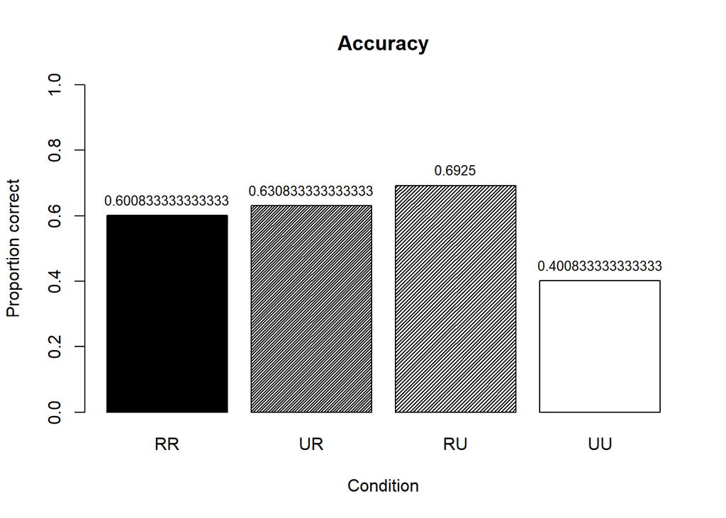

```r
#Calculate accuracy averages and sds for each levels of pair
meanAccSd<-ddply(datafile,~pair2,summarise,mean=mean(acc_vp),sd=sd(acc_vp))
#Plotting
accPlot<-barplot(meanAccSd$mean, main ="Accuracy",xlab="Condition",ylab="Proportion correct",ylim = c(0,1),names.arg = meanAccSd$pair2,col = "black", density = c(10000,50,40,0) )
text(accPlot, y = meanAccSd$mean, label = meanAccSd$mean, pos = 3, cex = 0.8, col = "black")
```

Participants in the RU group seems to score the highest amount of accuracy among all groups and Pariticpants from UU group scores the lowest scores.

## Question-9

# Distribution of reaction times

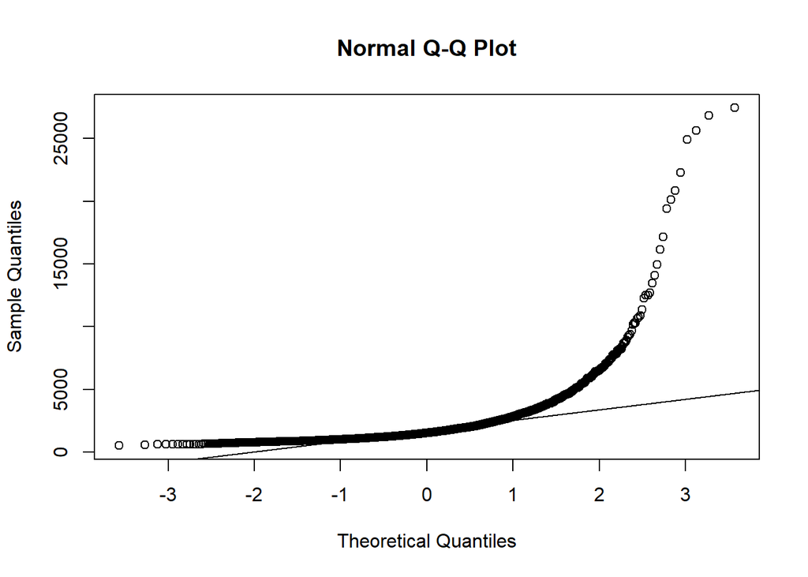

```r
#Let's first visualize the distribution of reaction times (data frame datafile_c, only correct reaction times) with a QQ-plot.
qqnorm(datafile_c$rt_vp)
qqline(datafile_c$rt_vp)
```

Looking at above graph, we can say that distribution of the values are not normally distributed. Towards the right of the graph there is a upwards tilt which informs us that the participants were giving their decisions with longer and longer reaction times. This makes one tail of a distribution incredibly pronounced which is the right in this case. Note that left tail(lower reaction times) is not a popular trend since it is impossible to under estimate the start of pressing button which is at 0ms, while it is possible to spend a lot of time thinking about the results.

## Question-9 Cont’d

# Distribution of reaction times

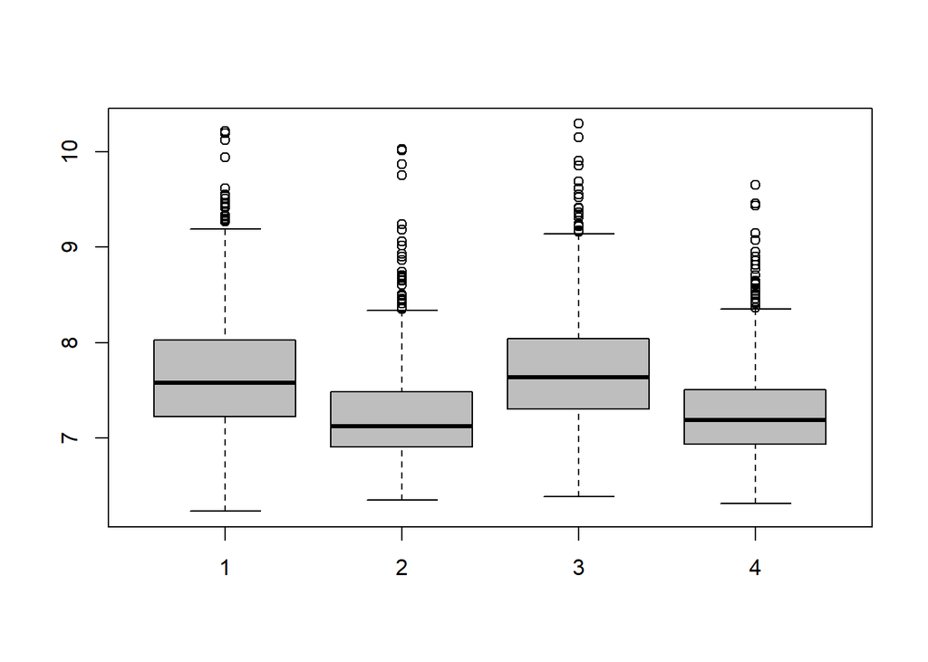

```r
#Visualize the distribution of log-transformed reaction times per condition with a box plot:
datafile$logRT <- log(datafile$rt_vp)
boxplot(logRT ~ pair, data=datafile, col='gray')
```

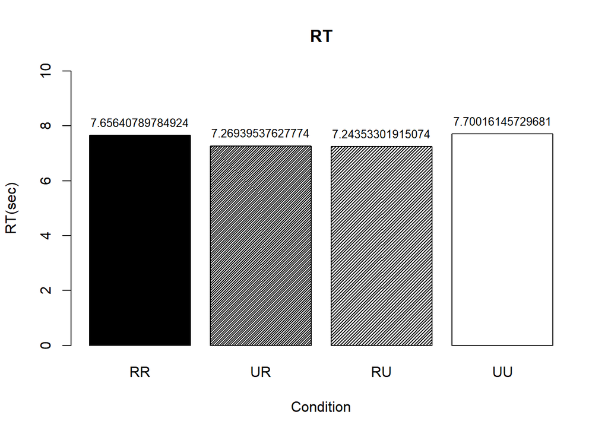

```r
#What can you infer from the box plot? Are the log-transformed reaction times normally distributed?
#group 1 and 3 have similiar means log transformed RT times while 2 and 4 have similiar means which means UU and RR city pairs cognitively have hair competition compared to UR/RU. Also the third quartlie group is always biggger than second which indicates the problem with the longer reaction times that caused non-normal distribution
#Calculate the averages per condition for the log-transformed reaction times, and visualize these in a bar plot. (See the earlier accuracy plot for an example.)
#Calculate reaction time averages and sds for each levels of pair
meanRTSd<-ddply(datafile,~pair2,summarise,mean=mean(logRT),sd=sd(logRT))

#Plotting
RTPlot<-barplot(meanRTSd$mean, main ="RT", xlab="Condition", ylab="RT(sec)", ylim = c(0,10), names.arg = meanRTSd$pair2, col = "black", density = c(10000,50,40,0) )
text(RTPlot, y = meanRTSd$mean, label = meanRTSd$mean, pos = 3, cex = 0.8, col = "black")
```

Group 1 and 3 have similiar means log transformed RT times while 2 and 4 have similiar means which means UU and RR city pairs cognitively have hair competition compared to UR/RU.

## Question-10

# Some function example

```r
#Calculate SE

se <- function(sd, n){
  result<- se/sqrt(n)
  return(result)
}

#Here we illustrate how one could plot the average accuracy per condition with standard errors that show the variation in participants averages:

# participant means:
subj <- ddply(datafile, c("Subject", "pair2"), summarise,
              acc_vp = mean(acc_vp))
# condition means with SE:
avg <- ddply(datafile, "pair2", summarise,
             acc = mean(acc_vp),
             se  = se(acc_vp))
```

[output not shown]

```r
# barplot:
b <- barplot(avg$acc, beside = TRUE,
             col=c(1,1,1,2), density=c(-1,25,25,-1),
             ylim=c(0,1),
             main="Accuracy", ylab="Proportion correct",
             xlab="Condition")
```

[output not shown]

```r
errorBars(b, avg$acc, avg$se)
```

[output not shown]

## Question-11

# Using ggplot

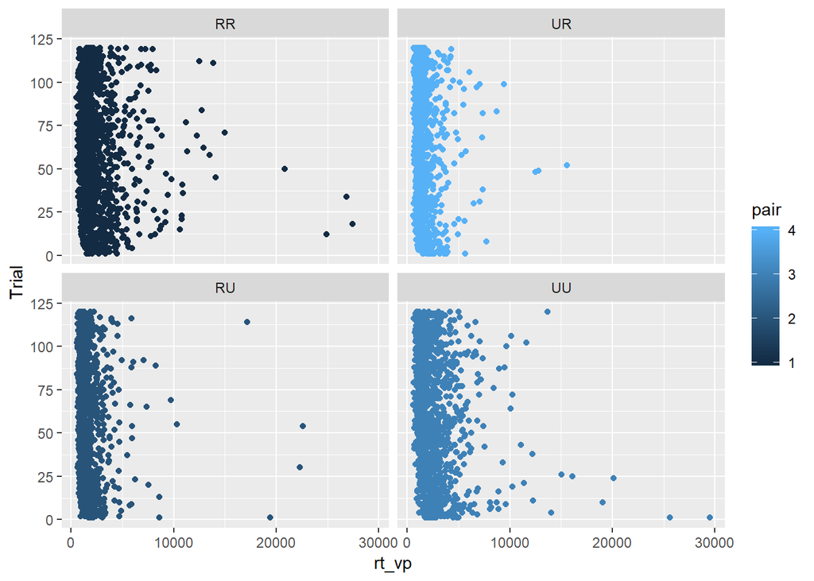

```r
#Up to now we have used the core-R package 'graphics' for plotting. However, many use the package 'ggplot2' for visualization, which works rather differently. Here is an example:
ggplot(datafile, aes(x = rt_vp, y = Trial, colour = pair)) +
geom_point() +
facet_wrap( ~ pair2)
```

## Question-12

# Saving

```r
save(datafile, file = "data_Assignment2.rda")
# do not forget to set the path if you want to save it not in the current directory
```

### Lab 1b: Linear model

## Preparations

```r
#rm(list = ls())
```

# Question 1&2: Aggregation & Inspection data

```r
datafile_avg <- ddply(datafile, ~Subject + pair, summarise,
                      meanRT = mean(rt_vp, na.rm=TRUE),
                      n.trials = length(rt_vp))
```

**How many observations you get overall as a result of manipulations?**

160 observations = 40 participants * 4 conditions

**How many observations there are per each subject?**

4

**How many observations you have per condition (recoded in pair)?**

40 obs for each codition

# Question 3: Distributions

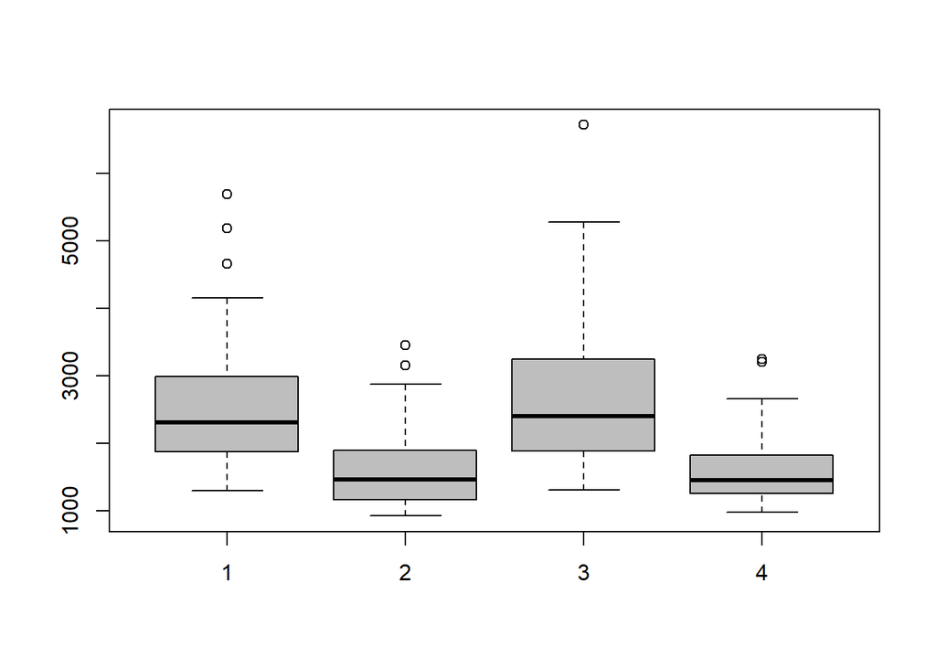

```r
#Make a boxplot of the reaction times, split by condition.
boxplot(meanRT ~ pair, data=datafile_avg, col='gray')
```

**Describe the reaction time distributions for the four conditions. Do you see differences between the conditions?** Yes there are differences. Basically group 1 and 3 && 2 and 4 are similiar

# Question 4: Transformation

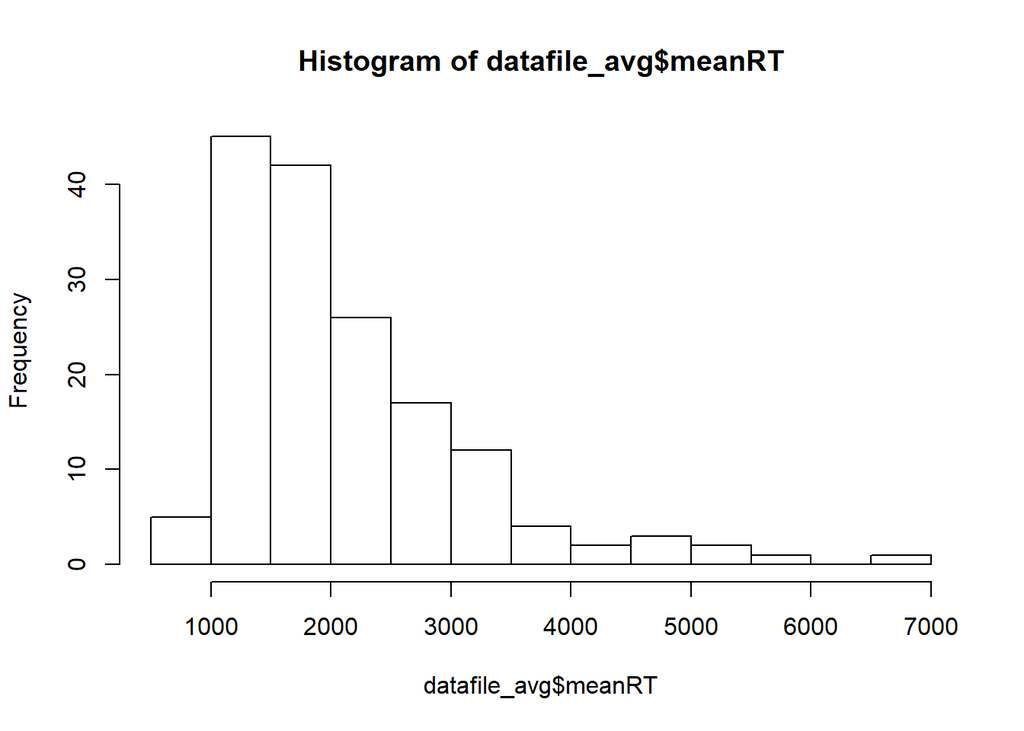

```r
#Make a histogram of the reaction times. Reaction times are generally not normally distributed. Describe the differences with a normal distribution.
hist(datafile_avg$meanRT)
```

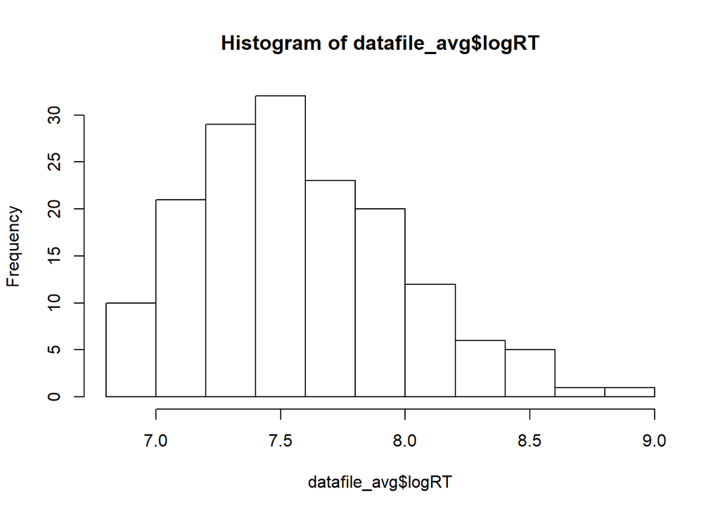

```r
#Reaction times are often transformed using a log-transformation, so that they approximate normally distributed data. Create a new column for log-reaction times, following the command below:
datafile_avg$logRT <- log(datafile_avg$meanRT)
#Make a new histogram of the log-transformed reaction times. Did the log transformation work?
hist(datafile_avg$logRT)
```

```r
#yes the transformation seems to work, there is still bit of right skewness though
```

The data is right skewed while the normal distribution does not have skewness

# Linear regression

## Question 5: Hypotheses

Hypothesis testing is like mathematical ‘’proof by contradiction’‘; if you want to prove something, then you assume that the opposite is true and using this’‘opposite is true’‘assumption you try to find a contradiction. As contradictions are impossible, the assumption’‘opposite is true’’ must be false.

**Research interest**: Is there an effect of pairing (based on pre-test) on mean reaction times between each experimental group level?

**Null hypothesis**: There is no difference between 4 groups **Alternate hypothesis**: There is a difference between groups

# Question 6: Linear regression model

```r
#Let's setup a linear regression model to investigate our hypotheses. First, we have to make sure that we deal with a factor variable. After creating such variable we will apply lm function that is built in R.
datafile_avg$pair <- factor(datafile_avg$pair)
is.factor(datafile_avg$pair)
```

```
## [1] TRUE
```

```r
#complete the lm model
lr_model <- lm( meanRT ~ pair , data = datafile_avg)
```

# Question 7: Interpretation of summary

```r
#Interpreting the results of a linear regression model. One of the first steps after regression analysis is to inspect summary, which presents the estimates of the coefficients and other useful information.
summary(lr_model)
```

```
##
## Call:
## lm(formula = meanRT ~ pair, data = datafile_avg)
##
## Residuals:
##     Min      1Q  Median      3Q     Max
## -1346.0  -521.1  -202.1   224.4  4059.9
##
## Coefficients:
##             Estimate Std. Error t value Pr(>|t|)
## (Intercept)  2608.92     139.83  18.658  < 2e-16 ***
## pair2        -974.27     197.74  -4.927 2.11e-06 ***
## pair3          45.84     197.74   0.232    0.817
## pair4        -977.49     197.74  -4.943 1.97e-06 ***
## ---
## Signif. codes:  0 '***' 0.001 '**' 0.01 '*' 0.05 '.' 0.1 ' ' 1
##
## Residual standard error: 884.3 on 156 degrees of freedom
## Multiple R-squared:  0.2467, Adjusted R-squared:  0.2322
## F-statistic: 17.03 on 3 and 156 DF,  p-value: 1.288e-09
```

**What does the intercept represent?** it is the B_o point which is the part of the line that passes through Y axis.

**What does the t-value of the intercept tell?** that the intercept is different than zero with very high confidence

**What does the value of pair2 represent?**

it means that pair 2 was lower than pair 1 in terms of reactiontimes by -974(ms)

**Based on the estimated coefficients, calculate the reaction time of pair 2 (R + U).**

**Based on the estimated coefficients, calculate the reaction time of pair 4 (R + U).**

**How large is the maximum and average difference between observed values and the predicted ones? (hint- you can look at residuals)?**

**What information is provided by the R2 statistics?**

it means the model accounts for 0.2467 of the variability in the data so this is not a good model actually

**Based on the summary, what is your conclusion about the effect of the conditions on the reaction times?**

group 2 and 4 have less competition therefore there is less noise to come up with a decision in the system compared to group 1 and 3

# Question 7: Confidence intervals

```r
#Examine the confidence intervals.
confint(lr_model)
```

```
##                  2.5 %    97.5 %
## (Intercept)  2332.7268 2885.1182
## pair2       -1364.8705 -583.6711
## pair3        -344.7622  436.4372
## pair4       -1368.0880 -586.8886
```

**What do the confidence intervals suggest about the differences between the conditions?**

# Question 8: Model predictions

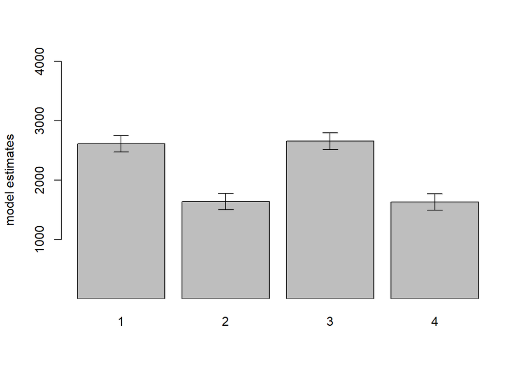

```r
#Visualizing the model predictions.
newd <- data.frame(pair=as.factor(1:4),
                   labels=c("RR", "RU", "UU", "UR"))
fv <- predict(lr_model, newd, se.fit=TRUE)

b <- barplot(fv$fit, beside = TRUE,
        ylab="model estimates",
        ylim=c(6,4000), xpd=FALSE)
errorBars(b, fv$fit, fv$se.fit)
```

**What is represented by the fitted values that are returned by the function predict?**

predicted mean reaction times for each condition

**Do the visualizations of the model predictions match your earlier conclusions based on the summary?**

yes the meanRT values for the pairs match closely to this current barplot

# Question 9: Model comparisons

```r
#Based on the model predictions that were visualized in question 8, we came up with an alternative explanation: if the cities are equally well-known, it takes more time to decide than when one of them is well-known, and the other not. We create a new predictor that captures these two categories and run a new linear regression model.

datafile_avg$Condition <- ifelse(datafile_avg$pair == 1 | datafile_avg$pair == 3 , 1, 2)
#turn into factors
datafile_avg$Condition <- factor(datafile_avg$Condition)
is.factor(datafile_avg$Condition)
```

```
## [1] TRUE
```

```r
#Below we compare what model fits the data best: a model with all four conditions, or a model with only labeled whether the two cities are equally well-known. Run the code.https://stats.stackexchange.com/questions/172157/how-to-interpret-an-anova-table-comparing-full-vs-reduced-ols-models

lr_model1 <- lm(logRT ~ pair, data=datafile_avg)
lr_model5 <- lm(logRT ~ Condition, data=datafile_avg)
anova(lr_model1, lr_model5)
```

```
## Analysis of Variance Table
##
## Model 1: logRT ~ pair
## Model 2: logRT ~ Condition
##   Res.Df    RSS Df  Sum of Sq      F Pr(>F)
## 1    156 19.078
## 2    158 19.082 -2 -0.0041313 0.0169 0.9833
```

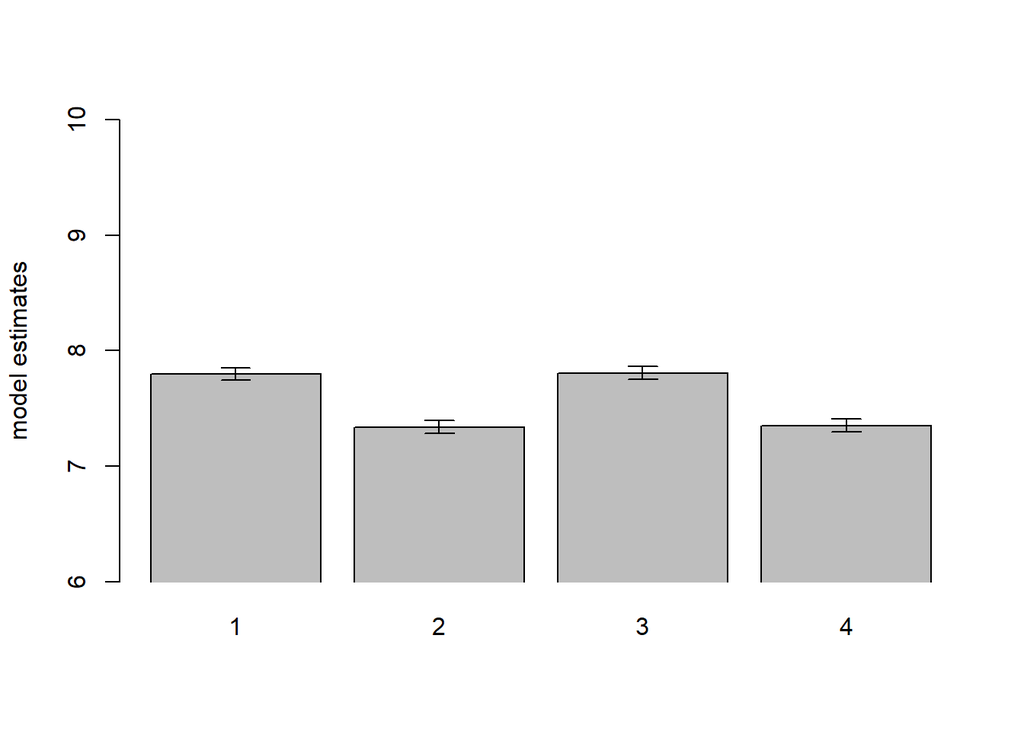

```r
#visualize lr_model1
fv <- predict(lr_model1, newd, se.fit=TRUE)

b <- barplot(fv$fit, beside = TRUE,
        ylab="model estimates",
        ylim=c(6,10), xpd=FALSE)
errorBars(b, fv$fit, fv$se.fit)
```

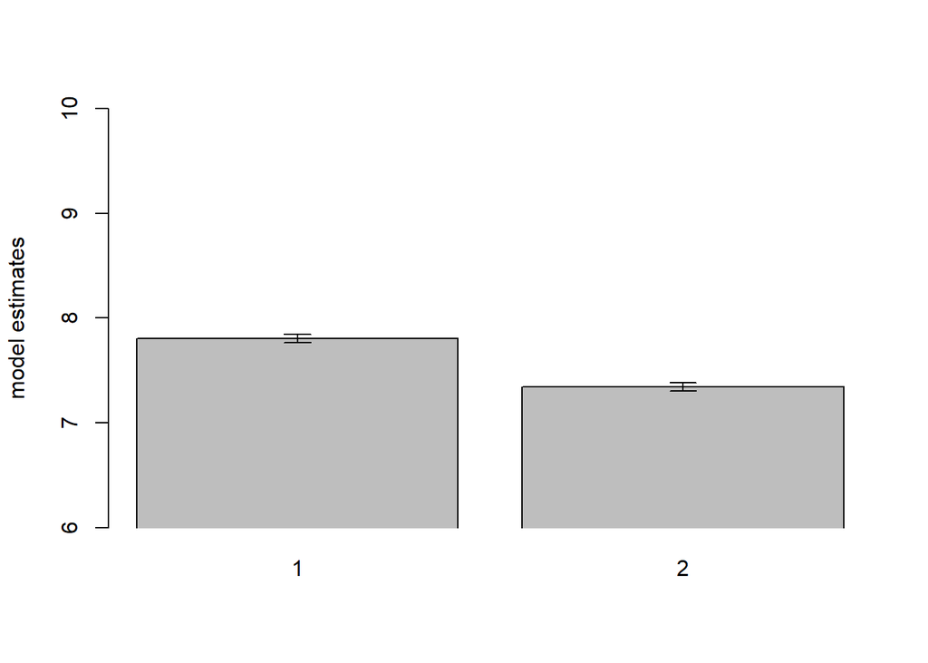

```r
#visualize lr_model2

newdd <- data.frame(Condition=as.factor(1:2),
                   labels=c("SAME", "DIFFERENT"))

fvv <- predict(lr_model5, newdd, se.fit=TRUE)

b <- barplot(fvv$fit, beside = TRUE,
        ylab="model estimates",
        ylim=c(6,10), xpd=FALSE)
errorBars(b, fvv$fit, fvv$se.fit)
```

**Interpret the output of the model comparison. Which model would you prefer?**

**Visualize the model predictions as illustrated in Question 8 for the model lr_model1 and lr_model2. Do these models fit the same patterns?**

Yes they fit the same patterns

# Question 10: Checking residuals

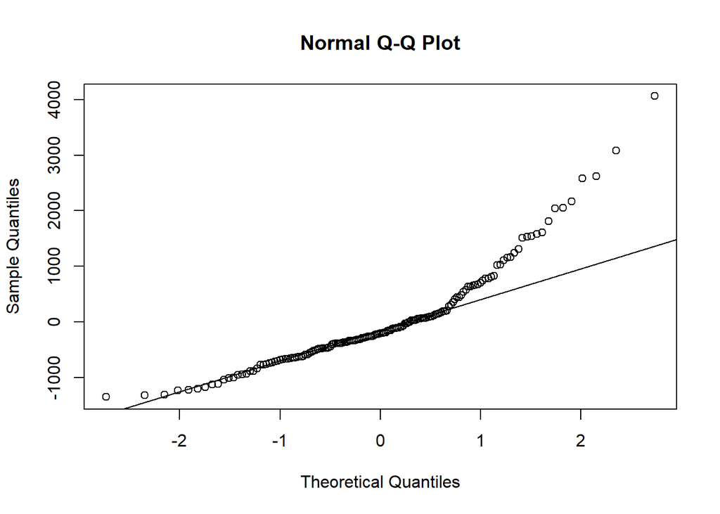

```r
#We visualize the residuals to see whether the residuals are normally distributed (one of the assumptions of linear regression).
#QQ-plot of the residuals:

qqnorm(resid(lr_model))
qqline(resid(lr_model))
```

**Describe the plot. What do we see on the x-axis and y-axis?**

y- quantiles with reaction times in ms, x - standard deviations

**What do you conclude: Are the residuals normally distributed?**

NO THEY are not